# Data Visualisation using RShiny: Day 1

Building exploratory plots

1.3 Guide

### Contents

Click to view a specific section of the document.

- The ggplot2 package
- Setting up a basic plot
- Customising plot appearence
- Plot type examples
- More Information

### The ggplot2 package

The ggplot2 package has a range of functions to allow easy and buildable plotting. It is designed so that all plotting functions take similar arguments, allowing users to quickly and easily build quite complicated plots.

### Setting up a basic plot

Plots in ggplot2 follow a simple basic structure. Here is an example using a barplot:

#### Step 1: Begin the plot

**ggplot() +**

#### Step 2: add a plot type

ggplot() +  
**geom_bar**()

#### Step 3: add the data

ggplot() +  
geom_bar(**data = raw_data**)  
**or**  
ggplot(**data = raw_data**) +  
geom_bar()

#### Step 4: specify the variables you want mapped

Here, we enclose mapping variables within the `aes()` function. This tells the plot what to show on the x-axis, y-axis etc. ggplot() +  
geom_bar(data = raw_data, **aes(x = species)**)

#### Complete code:

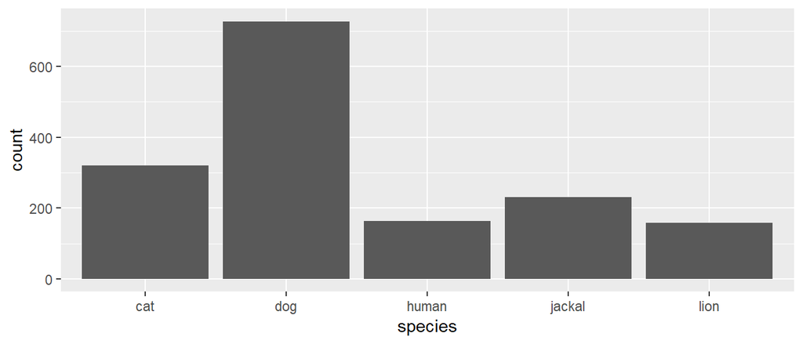

```r
ggplot() +
  geom_bar(data = raw_data, aes(x = species))
```

### Customising plot appearence

#### Changing plot colour

- You can change the overall colour with a named colour or a hex colour (*e.g. “#4E23B8”*)
- This can be `fill` or `color` depending on the plot type:

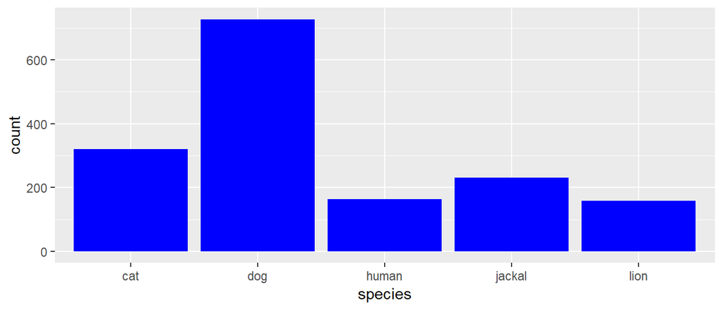

  ```r
  ggplot() +
    geom_bar(data = raw_data, aes(x = species), fill = "blue")
  ```

- Or you can set the fill colour to change with a variable:

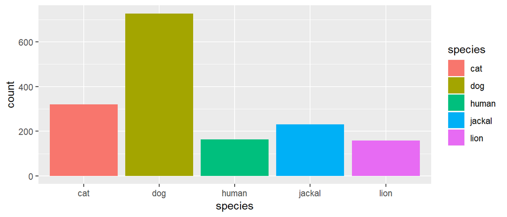

  ```r
  ggplot() +
    geom_bar(data = raw_data, aes(x = species, fill = species))
  ```

- The variable colour can be different to what is plotted on the x-axis:

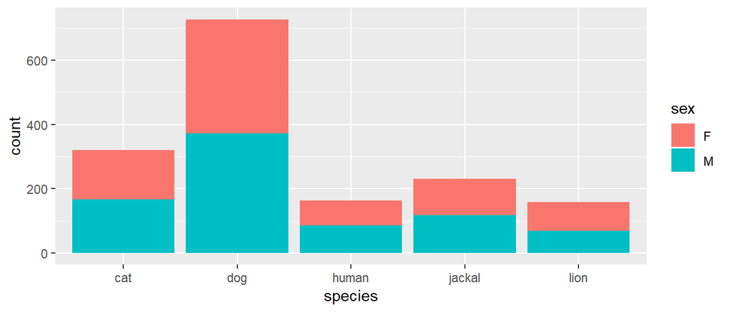

  ```r
  ggplot() +
    geom_bar(data = raw_data, aes(x = species, fill = sex))
  ```

#### Setting the plot colours that are mapped to variables

- To set the plot colour, you have to use either `scale_fill_...` or `scale_color_...` depending on the plot type:
- The RColorBrewer package contains a [list](https://www.r-graph-gallery.com/38-rcolorbrewers-palettes/) of freely available palettes you can use:

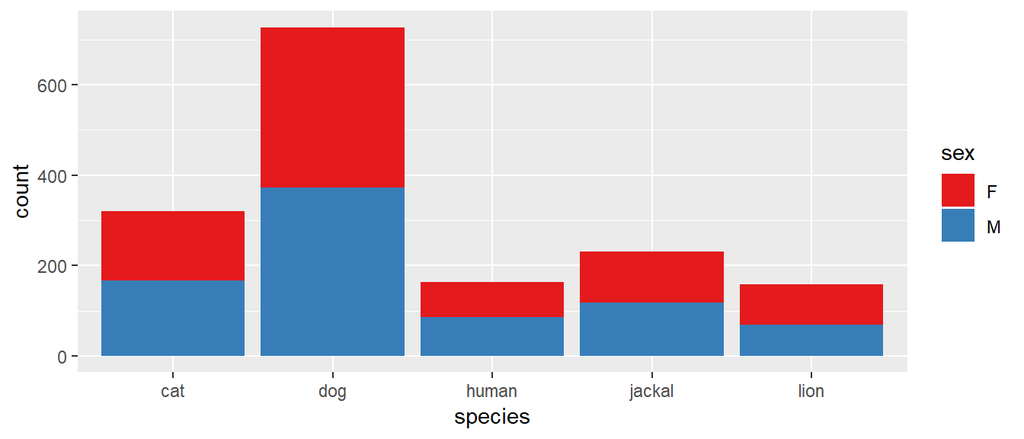

  ```r
  ggplot() +
    geom_bar(data = raw_data, aes(x = species, fill = sex)) +
    scale_fill_brewer(palette = "Set1")
  ```

- Alternatively, you can provide a vector of your own colour choices:

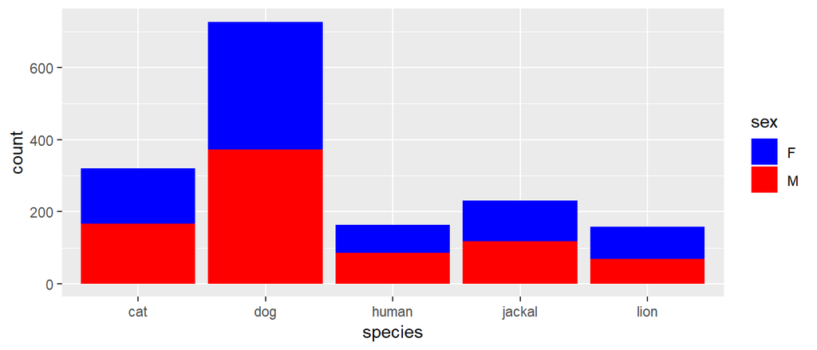

  ```r
  ggplot() +
    geom_bar(data = raw_data, aes(x = species, fill = sex)) +
    scale_fill_manual(values = c("blue", "red"))
  ```

#### Adding axis labels

- You can add axis labels easily with the `xlab()`, `ylab()` or `labs()` functions:

  ```r
  ggplot() +
    geom_bar(data = raw_data, aes(x = species), fill = "blue") +
    xlab("Species") +
    ylab("Cases")
  ```

  **or**

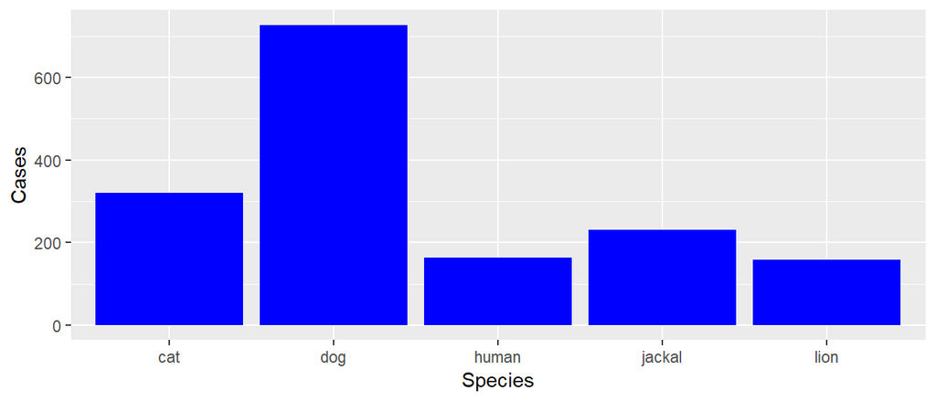

  ```r
  ggplot() +
    geom_bar(data = raw_data, aes(x = species), fill = "blue") +
    labs(x = "Species", y = "Cases")
  ```

#### Adding a plot title

- You can add a plot title and/or subtitle as part of the `labs()` function:

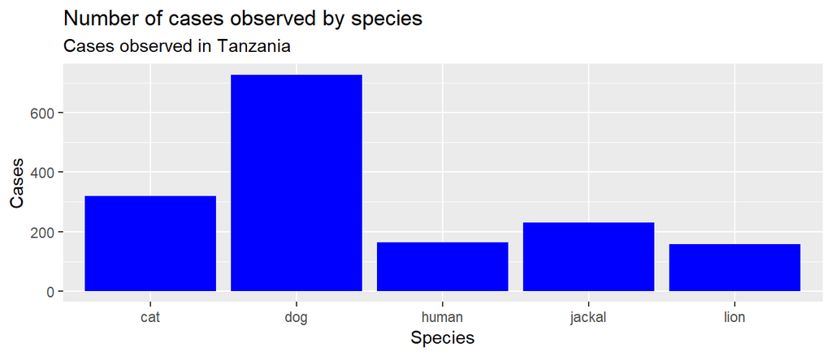

  ```r
  ggplot() +
    geom_bar(data = raw_data, aes(x = species), fill = "blue") +
    labs(x = "Species", y = "Cases",
         title = "Number of cases observed by species", subtitle = "Cases observed in Tanzania")
  ```

#### Adding a theme

- Themes can be a quick way to alter the appearence of your plot - our favourite is `theme_classic()`:

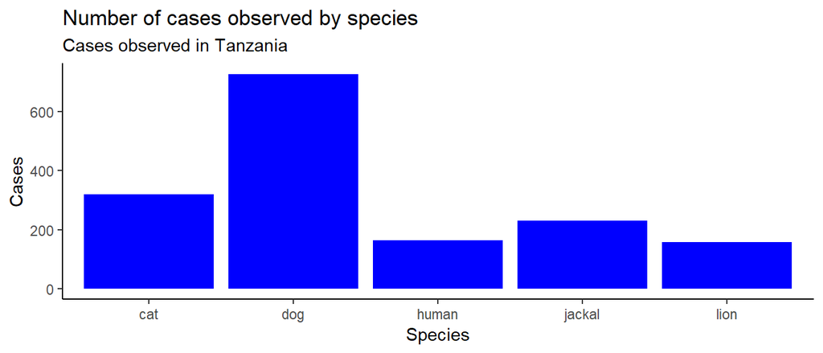

  ```r
  ggplot() +
    geom_bar(data = raw_data, aes(x = species), fill = "blue") +
    labs(x = "Species", y = "Cases",
         title = "Number of cases observed by species", subtitle = "Cases observed in Tanzania") +
    theme_classic()
  ```

### Plot type examples

- ggplot2 has individual functions for each type of plot
- There are also functions for additional plotting features such as lines, error bars and text.
- This allows the user to layer multiple plots easily e.g. bars and lines.
- We have provided some examples of different plots below:

### Common plots

#### geom_bar

Barplot, ggplot2 automatically counts totals provides by x

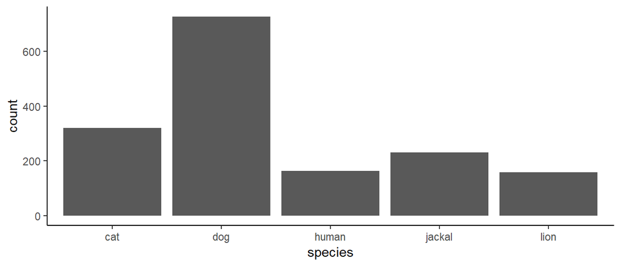

```r
ggplot() +
  geom_bar(data=raw_data,
           aes(x=species)) +
  theme_classic()
```

#### geom_col

Barplot, the user provides summary data for x and y

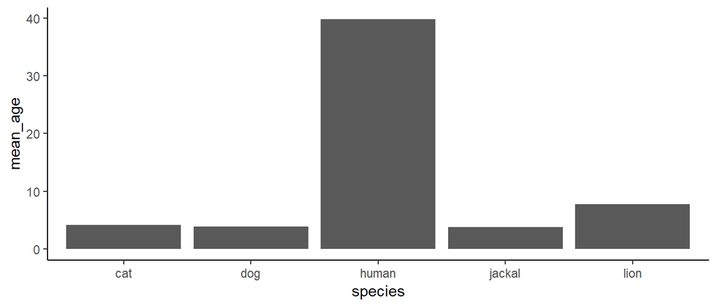

```r
ggplot() +
  geom_col(data=summary_data_means,
           aes(x=species, y=mean_age)) +
  theme_classic()
```

#### geom_histogram

Histogram, ggplot2 automatically counts totals along a continuous gradient

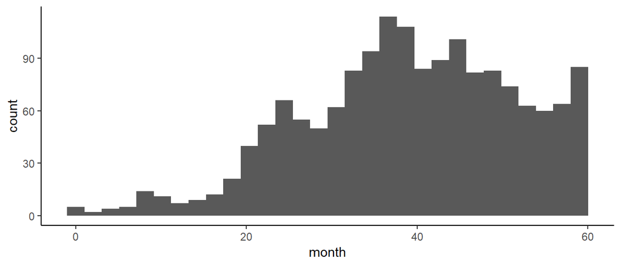

```r
ggplot() +
  geom_histogram(data=raw_data,
                 aes(x=month)) +
  theme_classic()
```

#### geom_point

Point/scatter, user provides x and y variables

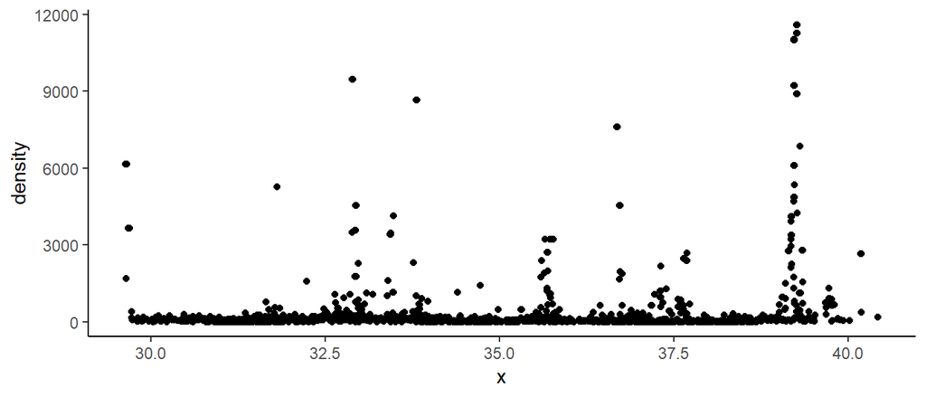

```r
ggplot() +
  geom_point(data=raw_data, aes(x=x, y=density)) +
  theme_classic()
```

#### geom_line

Lineplot, connects observations in the order they appear on the x-axis (e.g. over time)

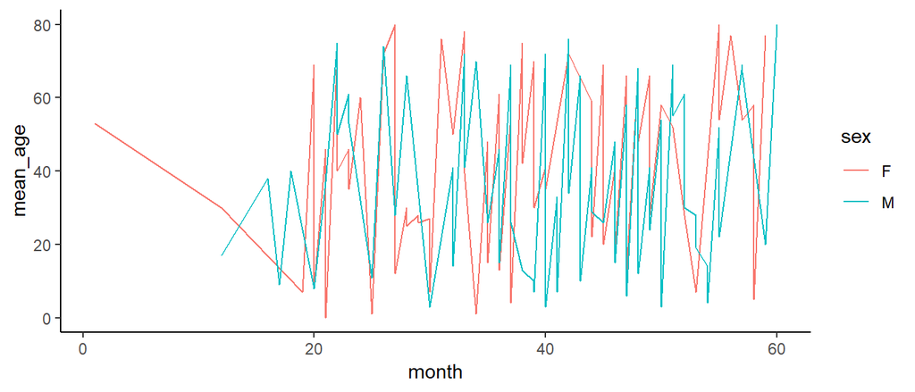

```r
ggplot() +
  geom_line(data=summary_data,
            aes(x=month, y=mean_age, color=sex)) +
  theme_classic()
```

#### geom_path

Lineplot, connects observation in the order they appear in the data (e.g. observation number)

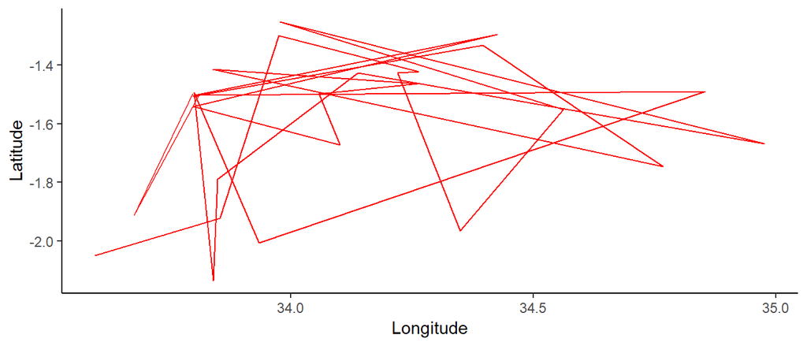

```r
ggplot() +
  geom_path(data=movement,
            aes(x=x, y=y), color="red") +
  labs(x="Longitude", y="Latitude") +
  theme_classic()
```

### Additional plots

#### geom_boxplot

Boxplot, draws boxes and outliers, user sets x and y

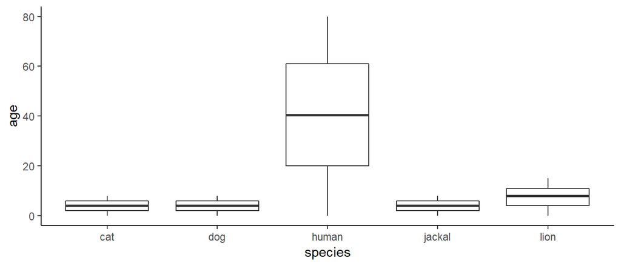

```r
ggplot() +
  geom_boxplot(data=raw_data,
             aes(x=species, y=age)) +
  theme_classic()
```

#### geom_polygon

Spatial polygons, data must be formatted as a data frame

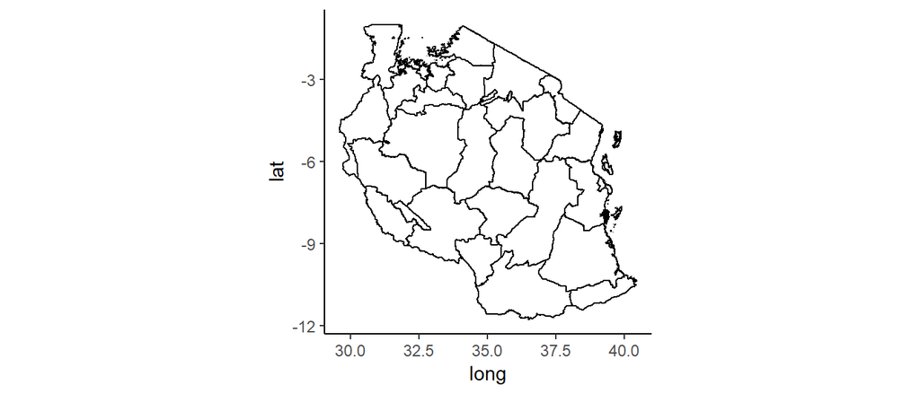

```r
ggplot() +
  geom_polygon(data=region_shp_df,
               aes(x=long, y=lat, group=group),
               fill="white", color="black") +
  theme_classic() + coord_equal()
```

### Layering plots

#### geom_polygon + geom_path

To layer multiple plots to one output, simply join with a `+` symbol

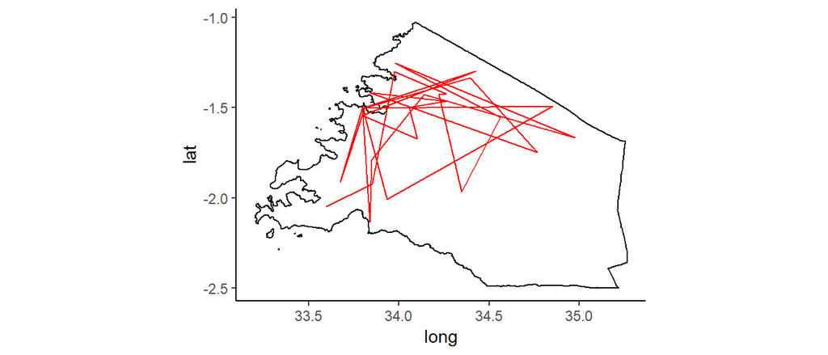

```r
ggplot() +
  geom_polygon(data=mara_shp_df,
               aes(x=long, y=lat, group=group),
               fill="white", color="black") +
  geom_path(data=movement,
            aes(x=x, y=y), color="red") +
  theme_classic() + coord_equal()
```

### Additional features

#### geom_abline, geom_hline and geom_vline

Diagonal, horizontal and vertical line plotting

```r
coef(lm(density~x, data=raw_data))
```

```
## (Intercept)           x
##  -5797.7112    187.4667
```

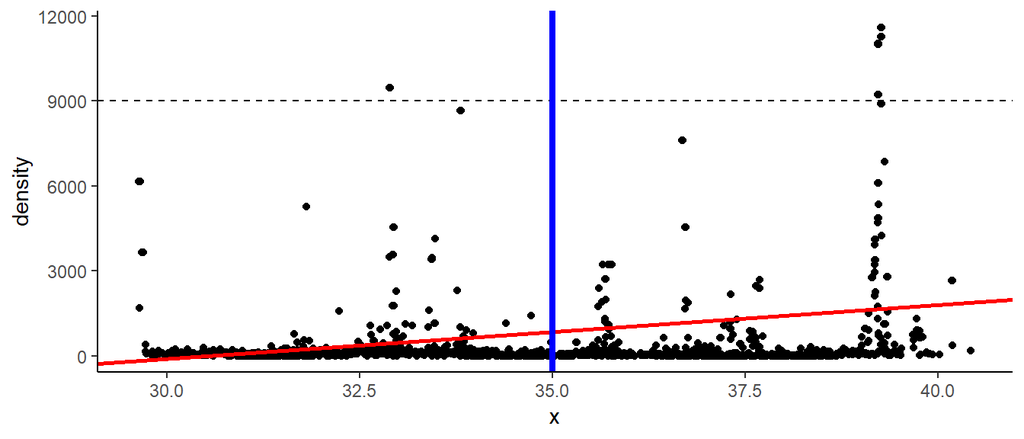

```r
ggplot() +
  geom_point(data=raw_data, aes(x=x, y=density)) +
  geom_abline(intercept=-5800, slope=190,
              color="red", size=1) +
  geom_hline(yintercept=9000, linetype="dashed") +
  geom_vline(xintercept=35, color="blue", size=1.5) +
  theme_classic()
```

#### geom_errorbar

Error bars matched to plot variables

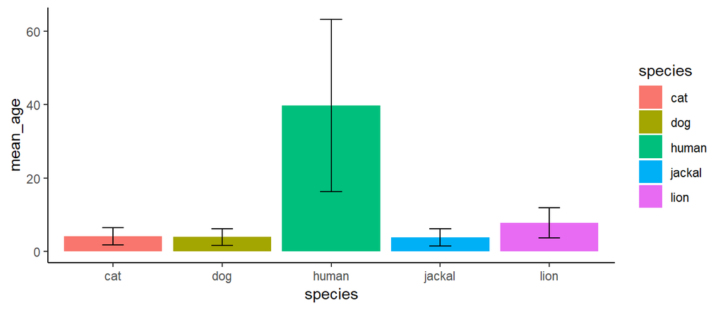

```r
ggplot(data=summary_data_means) +
  geom_col(aes(x=species, y=mean_age, fill=species)) +
  geom_errorbar(aes(x=species,
                    ymin=mean_age-sd_age,
                    ymax=mean_age+sd_age),
                width=0.2) +
  theme_classic()
```

#### geom_text and geom_label

Plot text from data frame with (geom_label) or without (geom_text) white background

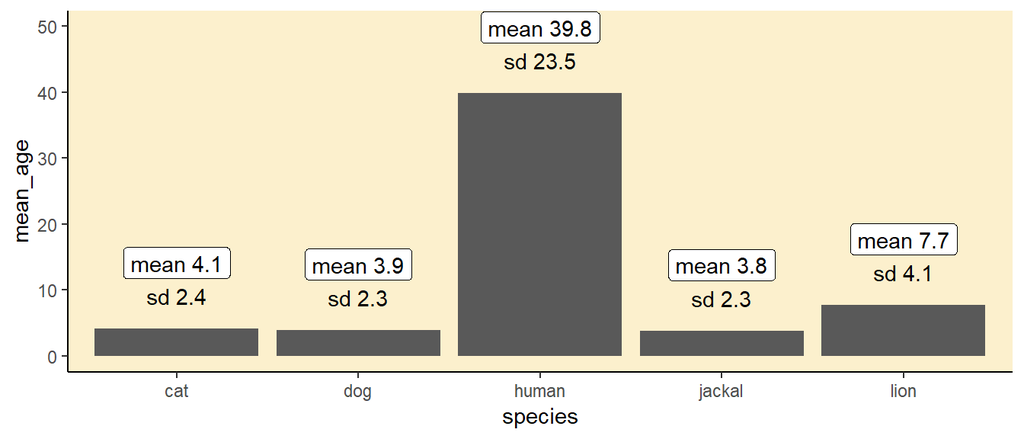

```r
ggplot(data=summary_data_means) +
  geom_col(aes(x=species, y=mean_age)) +
  geom_text(aes(x=species, y=mean_age+5,
                label=paste0("sd ", sd_age))) +
  geom_label(aes(x=species, y=mean_age+10,
                label=paste0("mean ", mean_age))) +
  theme_classic() +
  theme(panel.background = element_rect(fill="#fcf0cd"))
```

### More Information

There is **MUCH** more to ggplot2 than we have desccribed here!  
For more information on plot types and formatting plot appearence, see [here](https://ggplot2.tidyverse.org/reference/).